# More on Linear Regression

## Qualitatitive Predictors

```python
import pandas as pd
import numpy as np
```

```python
Credit=pd.read_csv('Credit.csv',index_col=0)
Credit.head()
```

|  | Income | Limit | Rating | Cards | Age | Education | Gender | Student | Married | Ethnicity | Balance |
| --- | --- | --- | --- | --- | --- | --- | --- | --- | --- | --- | --- |
| 1 | 14.891 | 3606 | 283 | 2 | 34 | 11 | Male | No | Yes | Caucasian | 333 |
| 2 | 106.025 | 6645 | 483 | 3 | 82 | 15 | Female | Yes | Yes | Asian | 903 |
| 3 | 104.593 | 7075 | 514 | 4 | 71 | 11 | Male | No | No | Asian | 580 |
| 4 | 148.924 | 9504 | 681 | 3 | 36 | 11 | Female | No | No | Asian | 964 |
| 5 | 55.882 | 4897 | 357 | 2 | 68 | 16 | Male | No | Yes | Caucasian | 331 |

If you want to know what these columns mean, you can check this pdf file: https://cran.r-project.org/web/packages/ISLR/ISLR.pdf

```python
import matplotlib.pyplot as plt
from pandas.plotting import scatter_matrix
```

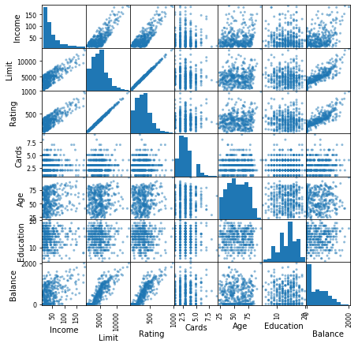

```python
scatter_matrix(Credit,figsize=(7,7))
plt.show()
```

```python
Credit.Ethnicity.unique()
```

```
array(['Caucasian', 'Asian', 'African American'], dtype=object)
```

```python
import statsmodels.formula.api as smf
results = smf.ols('Balance ~ Ethnicity', data=Credit).fit()
print(results.summary())
```

```
                            OLS Regression Results
==============================================================================
Dep. Variable:                Balance   R-squared:                       0.000
Model:                            OLS   Adj. R-squared:                 -0.005
Method:                 Least Squares   F-statistic:                   0.04344
Date:                Fri, 07 Feb 2020   Prob (F-statistic):              0.957
Time:                        09:16:00   Log-Likelihood:                -3019.3
No. Observations:                 400   AIC:                             6045.
Df Residuals:                     397   BIC:                             6057.
Df Model:                           2
Covariance Type:            nonrobust
==========================================================================================
                             coef    std err          t      P>|t|      [0.025      0.975]
------------------------------------------------------------------------------------------
Intercept                531.0000     46.319     11.464      0.000     439.939     622.061
Ethnicity[T.Asian]       -18.6863     65.021     -0.287      0.774    -146.515     109.142
Ethnicity[T.Caucasian]   -12.5025     56.681     -0.221      0.826    -123.935      98.930
==============================================================================
Omnibus:                       28.829   Durbin-Watson:                   1.946
Prob(Omnibus):                  0.000   Jarque-Bera (JB):               27.395
Skew:                           0.581   Prob(JB):                     1.13e-06
Kurtosis:                       2.460   Cond. No.                         4.39
==============================================================================

Warnings:
[1] Standard Errors assume that the covariance matrix of the errors is correctly specified.
```

```python
results.params
```

```
Intercept                 531.000000
Ethnicity[T.Asian]        -18.686275
Ethnicity[T.Caucasian]    -12.502513
dtype: float64
```

```python
results.params['Ethnicity[T.Asian]']
```

```
-18.686274509803397
```

```python
results.params['Ethnicity[T.Caucasian]']
```

```
-12.502512562813873
```

Note that $R^2$ is about 0 and adjusted R^2 is negative. This means that Ethnicity is not a good predictor. This is also supported by the p-value.

## Interaction between variables

The interaction term can be achieved by : in formula. Let's start with the interaction between two numerical predictors: Age and Income.

```python
results_AII = smf.ols('Balance ~ Age + Income + Age:Income', data=Credit).fit()
print(results_AII.summary())
```

```
                            OLS Regression Results
==============================================================================
Dep. Variable:                Balance   R-squared:                       0.223
Model:                            OLS   Adj. R-squared:                  0.217
Method:                 Least Squares   F-statistic:                     37.82
Date:                Fri, 07 Feb 2020   Prob (F-statistic):           1.63e-21
Time:                        09:16:00   Log-Likelihood:                -2969.0
No. Observations:                 400   AIC:                             5946.
Df Residuals:                     396   BIC:                             5962.
Df Model:                           3
Covariance Type:            nonrobust
==============================================================================
                 coef    std err          t      P>|t|      [0.025      0.975]
------------------------------------------------------------------------------
Intercept    429.6655    112.853      3.807      0.000     207.800     651.531
Age           -3.3944      1.939     -1.750      0.081      -7.207       0.418
Income         4.6981      2.025      2.320      0.021       0.717       8.679
Age:Income     0.0255      0.032      0.793      0.428      -0.038       0.089
==============================================================================
Omnibus:                       42.827   Durbin-Watson:                   1.944
Prob(Omnibus):                  0.000   Jarque-Bera (JB):               20.524
Skew:                           0.372   Prob(JB):                     3.49e-05
Kurtosis:                       2.177   Cond. No.                     2.01e+04
==============================================================================

Warnings:
[1] Standard Errors assume that the covariance matrix of the errors is correctly specified.
[2] The condition number is large, 2.01e+04. This might indicate that there are
strong multicollinearity or other numerical problems.
```

We can use * as well, in which case the individual variables are automatically included.

```python
results_AII = smf.ols('Balance ~ Age*Income', data=Credit).fit()
print(results_AII.summary())
```

```
                            OLS Regression Results
==============================================================================
Dep. Variable:                Balance   R-squared:                       0.223
Model:                            OLS   Adj. R-squared:                  0.217
Method:                 Least Squares   F-statistic:                     37.82
Date:                Fri, 07 Feb 2020   Prob (F-statistic):           1.63e-21
Time:                        09:16:00   Log-Likelihood:                -2969.0
No. Observations:                 400   AIC:                             5946.
Df Residuals:                     396   BIC:                             5962.
Df Model:                           3
Covariance Type:            nonrobust
==============================================================================
                 coef    std err          t      P>|t|      [0.025      0.975]
------------------------------------------------------------------------------
Intercept    429.6655    112.853      3.807      0.000     207.800     651.531
Age           -3.3944      1.939     -1.750      0.081      -7.207       0.418
Income         4.6981      2.025      2.320      0.021       0.717       8.679
Age:Income     0.0255      0.032      0.793      0.428      -0.038       0.089
==============================================================================
Omnibus:                       42.827   Durbin-Watson:                   1.944
Prob(Omnibus):                  0.000   Jarque-Bera (JB):               20.524
Skew:                           0.372   Prob(JB):                     3.49e-05
Kurtosis:                       2.177   Cond. No.                     2.01e+04
==============================================================================

Warnings:
[1] Standard Errors assume that the covariance matrix of the errors is correctly specified.
[2] The condition number is large, 2.01e+04. This might indicate that there are
strong multicollinearity or other numerical problems.
```

p-value for the interaction is large, so we might want to drop it.

```python
results_AI = smf.ols('Balance ~ Age + Income', data=Credit).fit()
print(results_AI.summary())
```

```
                            OLS Regression Results
==============================================================================
Dep. Variable:                Balance   R-squared:                       0.221
Model:                            OLS   Adj. R-squared:                  0.218
Method:                 Least Squares   F-statistic:                     56.47
Date:                Fri, 07 Feb 2020   Prob (F-statistic):           2.60e-22
Time:                        09:16:00   Log-Likelihood:                -2969.3
No. Observations:                 400   AIC:                             5945.
Df Residuals:                     397   BIC:                             5957.
Df Model:                           2
Covariance Type:            nonrobust
==============================================================================
                 coef    std err          t      P>|t|      [0.025      0.975]
------------------------------------------------------------------------------
Intercept    359.6727     70.358      5.112      0.000     221.351     497.994
Age           -2.1851      1.199     -1.823      0.069      -4.542       0.172
Income         6.2359      0.587     10.628      0.000       5.082       7.389
==============================================================================
Omnibus:                       42.191   Durbin-Watson:                   1.947
Prob(Omnibus):                  0.000   Jarque-Bera (JB):               20.272
Skew:                           0.369   Prob(JB):                     3.96e-05
Kurtosis:                       2.180   Cond. No.                         267.
==============================================================================

Warnings:
[1] Standard Errors assume that the covariance matrix of the errors is correctly specified.
```

$R^2$ drop from 0.223 to 0.221, not significantly. So it is better not to include the interaction.

How about the interaction between Income and Student? Note that Student is a qualitative predictor.

```python
results_IS = smf.ols('Balance ~ Income + Student' , data=Credit).fit()
print(results_IS.summary())
```

```
                            OLS Regression Results
==============================================================================
Dep. Variable:                Balance   R-squared:                       0.277
Model:                            OLS   Adj. R-squared:                  0.274
Method:                 Least Squares   F-statistic:                     76.22
Date:                Fri, 07 Feb 2020   Prob (F-statistic):           9.64e-29
Time:                        09:16:00   Log-Likelihood:                -2954.4
No. Observations:                 400   AIC:                             5915.
Df Residuals:                     397   BIC:                             5927.
Df Model:                           2
Covariance Type:            nonrobust
==================================================================================
                     coef    std err          t      P>|t|      [0.025      0.975]
----------------------------------------------------------------------------------
Intercept        211.1430     32.457      6.505      0.000     147.333     274.952
Student[T.Yes]   382.6705     65.311      5.859      0.000     254.272     511.069
Income             5.9843      0.557     10.751      0.000       4.890       7.079
==============================================================================
Omnibus:                      119.719   Durbin-Watson:                   1.951
Prob(Omnibus):                  0.000   Jarque-Bera (JB):               23.617
Skew:                           0.252   Prob(JB):                     7.44e-06
Kurtosis:                       1.922   Cond. No.                         192.
==============================================================================

Warnings:
[1] Standard Errors assume that the covariance matrix of the errors is correctly specified.
```

```python
results_ISI = smf.ols('Balance ~ Income + Student + Income:Student' , data=Credit).fit()
print(results_ISI.summary())
```

```
                            OLS Regression Results
==============================================================================
Dep. Variable:                Balance   R-squared:                       0.280
Model:                            OLS   Adj. R-squared:                  0.274
Method:                 Least Squares   F-statistic:                     51.30
Date:                Fri, 07 Feb 2020   Prob (F-statistic):           4.94e-28
Time:                        09:16:00   Log-Likelihood:                -2953.7
No. Observations:                 400   AIC:                             5915.
Df Residuals:                     396   BIC:                             5931.
Df Model:                           3
Covariance Type:            nonrobust
=========================================================================================
                            coef    std err          t      P>|t|      [0.025      0.975]
-----------------------------------------------------------------------------------------
Intercept               200.6232     33.698      5.953      0.000     134.373     266.873
Student[T.Yes]          476.6758    104.351      4.568      0.000     271.524     681.827
Income                    6.2182      0.592     10.502      0.000       5.054       7.382
Income:Student[T.Yes]    -1.9992      1.731     -1.155      0.249      -5.403       1.404
==============================================================================
Omnibus:                      107.788   Durbin-Watson:                   1.952
Prob(Omnibus):                  0.000   Jarque-Bera (JB):               22.158
Skew:                           0.228   Prob(JB):                     1.54e-05
Kurtosis:                       1.941   Cond. No.                         309.
==============================================================================

Warnings:
[1] Standard Errors assume that the covariance matrix of the errors is correctly specified.
```

p-value for the interaction is large and the $R^2$ increase is not significant by adding the interaction. So still it is not significant to include the interaction.

## Non-linear Relationship

Use Auto dataset

```python
Auto=pd.read_csv('Auto.csv',index_col=0)
Auto.head()
```

|  | mpg | cylinders | displacement | horsepower | weight | acceleration | year | origin | name |
| --- | --- | --- | --- | --- | --- | --- | --- | --- | --- |
| 1 | 18.0 | 8 | 307.0 | 130 | 3504 | 12.0 | 70 | 1 | chevrolet chevelle malibu |
| 2 | 15.0 | 8 | 350.0 | 165 | 3693 | 11.5 | 70 | 1 | buick skylark 320 |
| 3 | 18.0 | 8 | 318.0 | 150 | 3436 | 11.0 | 70 | 1 | plymouth satellite |
| 4 | 16.0 | 8 | 304.0 | 150 | 3433 | 12.0 | 70 | 1 | amc rebel sst |
| 5 | 17.0 | 8 | 302.0 | 140 | 3449 | 10.5 | 70 | 1 | ford torino |

We first regress mpg on horsepower

```python
results_p = smf.ols('mpg ~ horsepower' , data=Auto).fit()
print(results_p.summary())
```

```
                            OLS Regression Results
==============================================================================
Dep. Variable:                    mpg   R-squared:                       0.606
Model:                            OLS   Adj. R-squared:                  0.605
Method:                 Least Squares   F-statistic:                     599.7
Date:                Fri, 07 Feb 2020   Prob (F-statistic):           7.03e-81
Time:                        09:16:00   Log-Likelihood:                -1178.7
No. Observations:                 392   AIC:                             2361.
Df Residuals:                     390   BIC:                             2369.
Df Model:                           1
Covariance Type:            nonrobust
==============================================================================
                 coef    std err          t      P>|t|      [0.025      0.975]
------------------------------------------------------------------------------
Intercept     39.9359      0.717     55.660      0.000      38.525      41.347
horsepower    -0.1578      0.006    -24.489      0.000      -0.171      -0.145
==============================================================================
Omnibus:                       16.432   Durbin-Watson:                   0.920
Prob(Omnibus):                  0.000   Jarque-Bera (JB):               17.305
Skew:                           0.492   Prob(JB):                     0.000175
Kurtosis:                       3.299   Cond. No.                         322.
==============================================================================

Warnings:
[1] Standard Errors assume that the covariance matrix of the errors is correctly specified.
```

```python
results_p2 = smf.ols('mpg ~ horsepower + I(horsepower**2)' , data=Auto).fit()
print(results_p2.summary())
```

```
                            OLS Regression Results
==============================================================================
Dep. Variable:                    mpg   R-squared:                       0.688
Model:                            OLS   Adj. R-squared:                  0.686
Method:                 Least Squares   F-statistic:                     428.0
Date:                Fri, 07 Feb 2020   Prob (F-statistic):           5.40e-99
Time:                        09:16:00   Log-Likelihood:                -1133.2
No. Observations:                 392   AIC:                             2272.
Df Residuals:                     389   BIC:                             2284.
Df Model:                           2
Covariance Type:            nonrobust
======================================================================================
                         coef    std err          t      P>|t|      [0.025      0.975]
--------------------------------------------------------------------------------------
Intercept             56.9001      1.800     31.604      0.000      53.360      60.440
horsepower            -0.4662      0.031    -14.978      0.000      -0.527      -0.405
I(horsepower ** 2)     0.0012      0.000     10.080      0.000       0.001       0.001
==============================================================================
Omnibus:                       16.158   Durbin-Watson:                   1.078
Prob(Omnibus):                  0.000   Jarque-Bera (JB):               30.662
Skew:                           0.218   Prob(JB):                     2.20e-07
Kurtosis:                       4.299   Cond. No.                     1.29e+05
==============================================================================

Warnings:
[1] Standard Errors assume that the covariance matrix of the errors is correctly specified.
[2] The condition number is large, 1.29e+05. This might indicate that there are
strong multicollinearity or other numerical problems.
```

We can include more powers.

```python
results_p4 = smf.ols('mpg ~ horsepower + I(horsepower**2)+I(horsepower**3)+I(horsepower**4)' , data=Auto).fit()
print(results_p4.summary())
```

```
                            OLS Regression Results
==============================================================================
Dep. Variable:                    mpg   R-squared:                       0.689
Model:                            OLS   Adj. R-squared:                  0.686
Method:                 Least Squares   F-statistic:                     214.7
Date:                Fri, 07 Feb 2020   Prob (F-statistic):           7.67e-97
Time:                        09:16:00   Log-Likelihood:                -1132.1
No. Observations:                 392   AIC:                             2274.
Df Residuals:                     387   BIC:                             2294.
Df Model:                           4
Covariance Type:            nonrobust
======================================================================================
                         coef    std err          t      P>|t|      [0.025      0.975]
--------------------------------------------------------------------------------------
Intercept             47.5677     11.960      3.977      0.000      24.053      71.082
horsepower            -0.0767      0.431     -0.178      0.859      -0.925       0.771
I(horsepower ** 2)    -0.0043      0.005     -0.790      0.430      -0.015       0.006
I(horsepower ** 3)  3.245e-05   2.93e-05      1.109      0.268   -2.51e-05       9e-05
I(horsepower ** 4)  -6.53e-08    5.5e-08     -1.186      0.236   -1.74e-07    4.29e-08
==============================================================================
Omnibus:                       17.221   Durbin-Watson:                   1.090
Prob(Omnibus):                  0.000   Jarque-Bera (JB):               33.332
Skew:                           0.232   Prob(JB):                     5.78e-08
Kurtosis:                       4.351   Cond. No.                     2.73e+10
==============================================================================

Warnings:
[1] Standard Errors assume that the covariance matrix of the errors is correctly specified.
[2] The condition number is large, 2.73e+10. This might indicate that there are
strong multicollinearity or other numerical problems.
```

```python
results_p5 = smf.ols('mpg ~ horsepower + I(horsepower**2)+I(horsepower**3)+I(horsepower**4)+I(horsepower**5)' , data=Auto).fit()
print(results_p5.summary())
```

```
                            OLS Regression Results
==============================================================================
Dep. Variable:                    mpg   R-squared:                       0.697
Model:                            OLS   Adj. R-squared:                  0.693
Method:                 Least Squares   F-statistic:                     177.4
Date:                Fri, 07 Feb 2020   Prob (F-statistic):           1.16e-97
Time:                        09:16:00   Log-Likelihood:                -1127.3
No. Observations:                 392   AIC:                             2267.
Df Residuals:                     386   BIC:                             2290.
Df Model:                           5
Covariance Type:            nonrobust
======================================================================================
                         coef    std err          t      P>|t|      [0.025      0.975]
--------------------------------------------------------------------------------------
Intercept            -32.2306     28.574     -1.128      0.260     -88.411      23.950
horsepower             3.7001      1.303      2.840      0.005       1.139       6.262
I(horsepower ** 2)    -0.0714      0.023     -3.170      0.002      -0.116      -0.027
I(horsepower ** 3)     0.0006      0.000      3.206      0.001       0.000       0.001
I(horsepower ** 4) -2.281e-06   7.24e-07     -3.150      0.002   -3.71e-06   -8.57e-07
I(horsepower ** 5)   3.33e-09   1.09e-09      3.068      0.002     1.2e-09    5.46e-09
==============================================================================
Omnibus:                       20.902   Durbin-Watson:                   1.113
Prob(Omnibus):                  0.000   Jarque-Bera (JB):               40.260
Skew:                           0.305   Prob(JB):                     1.81e-09
Kurtosis:                       4.447   Cond. No.                     1.32e+13
==============================================================================

Warnings:
[1] Standard Errors assume that the covariance matrix of the errors is correctly specified.
[2] The condition number is large, 1.32e+13. This might indicate that there are
strong multicollinearity or other numerical problems.
```

```python
results_p6 = smf.ols('mpg ~ horsepower + I(horsepower**2)+I(horsepower**3)+I(horsepower**4)+I(horsepower**5)+I(horsepower**6)' , data=Auto).fit()
print(results_p6.summary())
```

```
                            OLS Regression Results
==============================================================================
Dep. Variable:                    mpg   R-squared:                       0.696
Model:                            OLS   Adj. R-squared:                  0.692
Method:                 Least Squares   F-statistic:                     176.6
Date:                Fri, 07 Feb 2020   Prob (F-statistic):           2.13e-97
Time:                        09:16:00   Log-Likelihood:                -1128.0
No. Observations:                 392   AIC:                             2268.
Df Residuals:                     386   BIC:                             2292.
Df Model:                           5
Covariance Type:            nonrobust
======================================================================================
                         coef    std err          t      P>|t|      [0.025      0.975]
--------------------------------------------------------------------------------------
Intercept              0.1204      0.020      5.999      0.000       0.081       0.160
horsepower             2.1490      0.358      6.002      0.000       1.445       2.853
I(horsepower ** 2)    -0.0428      0.015     -2.825      0.005      -0.073      -0.013
I(horsepower ** 3)     0.0003      0.000      1.364      0.173      -0.000       0.001
I(horsepower ** 4) -1.048e-06   1.87e-06     -0.561      0.575   -4.72e-06    2.62e-06
I(horsepower ** 5)  4.893e-10   6.86e-09      0.071      0.943    -1.3e-08     1.4e-08
I(horsepower ** 6)  2.438e-12    9.7e-12      0.251      0.802   -1.66e-11    2.15e-11
==============================================================================
Omnibus:                       19.656   Durbin-Watson:                   1.106
Prob(Omnibus):                  0.000   Jarque-Bera (JB):               38.339
Skew:                           0.277   Prob(JB):                     4.73e-09
Kurtosis:                       4.428   Cond. No.                     6.86e+15
==============================================================================

Warnings:
[1] Standard Errors assume that the covariance matrix of the errors is correctly specified.
[2] The condition number is large, 6.86e+15. This might indicate that there are
strong multicollinearity or other numerical problems.
```

We can also do other transformations using np operators.

```python
results_log = smf.ols('mpg ~ np.log(horsepower)' , data=Auto).fit()
print(results_log.summary())
```

```
                            OLS Regression Results
==============================================================================
Dep. Variable:                    mpg   R-squared:                       0.668
Model:                            OLS   Adj. R-squared:                  0.667
Method:                 Least Squares   F-statistic:                     785.9
Date:                Fri, 07 Feb 2020   Prob (F-statistic):           1.70e-95
Time:                        09:16:00   Log-Likelihood:                -1144.9
No. Observations:                 392   AIC:                             2294.
Df Residuals:                     390   BIC:                             2302.
Df Model:                           1
Covariance Type:            nonrobust
======================================================================================
                         coef    std err          t      P>|t|      [0.025      0.975]
--------------------------------------------------------------------------------------
Intercept            108.6997      3.050     35.644      0.000     102.704     114.695
np.log(horsepower)   -18.5822      0.663    -28.034      0.000     -19.885     -17.279
==============================================================================
Omnibus:                       11.919   Durbin-Watson:                   1.031
Prob(Omnibus):                  0.003   Jarque-Bera (JB):               15.557
Skew:                           0.278   Prob(JB):                     0.000419
Kurtosis:                       3.803   Cond. No.                         64.6
==============================================================================

Warnings:
[1] Standard Errors assume that the covariance matrix of the errors is correctly specified.
```

In the formula, if you want to exclude the intercept, you can use -1 in the formula. But be careful, we usually should not drop the intercept unless you have a very strong evidence that the intercept is zero.

```python
results_noin = smf.ols('mpg ~ horsepower-1' , data=Auto).fit()
print(results_noin.summary())
```

```
                                 OLS Regression Results
=======================================================================================
Dep. Variable:                    mpg   R-squared (uncentered):                   0.649
Model:                            OLS   Adj. R-squared (uncentered):              0.648
Method:                 Least Squares   F-statistic:                              723.7
Date:                Fri, 07 Feb 2020   Prob (F-statistic):                    5.67e-91
Time:                        09:16:00   Log-Likelihood:                         -1608.1
No. Observations:                 392   AIC:                                      3218.
Df Residuals:                     391   BIC:                                      3222.
Df Model:                           1
Covariance Type:            nonrobust
==============================================================================
                 coef    std err          t      P>|t|      [0.025      0.975]
------------------------------------------------------------------------------
horsepower     0.1788      0.007     26.901      0.000       0.166       0.192
==============================================================================
Omnibus:                       13.847   Durbin-Watson:                   0.471
Prob(Omnibus):                  0.001   Jarque-Bera (JB):                9.780
Skew:                          -0.268   Prob(JB):                      0.00752
Kurtosis:                       2.442   Cond. No.                         1.00
==============================================================================

Warnings:
[1] Standard Errors assume that the covariance matrix of the errors is correctly specified.
```

In this case, $R^2$ is defined in a different way. So you can not compare $R^2$ or Adjusted $R^2$ with those model that has intercept.

## Make numerical variable categorical

Sometimes, a predictor has numerical value, but you believe the magitute does not have any information. In this case, you should make it a categorical variable. For instance, in Auto dataset, Origin means the origin of car (1. American, 2. European, 3. Japanese).

```python
Auto.origin.unique()
```

```
array([1, 3, 2])
```

In this case, these numerical value is meaningless. In this case, regression on this predictor could be misleading.

```python
results_or = smf.ols('mpg ~ origin' , data=Auto).fit()
print(results_or.summary())
```

```
                            OLS Regression Results
==============================================================================
Dep. Variable:                    mpg   R-squared:                       0.319
Model:                            OLS   Adj. R-squared:                  0.318
Method:                 Least Squares   F-statistic:                     183.1
Date:                Fri, 07 Feb 2020   Prob (F-statistic):           1.81e-34
Time:                        09:16:00   Log-Likelihood:                -1285.8
No. Observations:                 392   AIC:                             2576.
Df Residuals:                     390   BIC:                             2583.
Df Model:                           1
Covariance Type:            nonrobust
==============================================================================
                 coef    std err          t      P>|t|      [0.025      0.975]
------------------------------------------------------------------------------
Intercept     14.8120      0.716     20.676      0.000      13.404      16.220
origin         5.4765      0.405     13.531      0.000       4.681       6.272
==============================================================================
Omnibus:                       26.546   Durbin-Watson:                   0.829
Prob(Omnibus):                  0.000   Jarque-Bera (JB):               30.323
Skew:                           0.678   Prob(JB):                     2.60e-07
Kurtosis:                       3.138   Cond. No.                         4.93
==============================================================================

Warnings:
[1] Standard Errors assume that the covariance matrix of the errors is correctly specified.
```

There are two ways to make the variable categorical. The first option is to make the data type as a string.

```python
Auto['origin_str']=Auto['origin'].astype(str)
results_orc = smf.ols('mpg ~ origin_str' , data=Auto).fit()
print(results_orc.summary())
```

```
                            OLS Regression Results
==============================================================================
Dep. Variable:                    mpg   R-squared:                       0.332
Model:                            OLS   Adj. R-squared:                  0.328
Method:                 Least Squares   F-statistic:                     96.60
Date:                Fri, 07 Feb 2020   Prob (F-statistic):           8.67e-35
Time:                        09:16:00   Log-Likelihood:                -1282.2
No. Observations:                 392   AIC:                             2570.
Df Residuals:                     389   BIC:                             2582.
Df Model:                           2
Covariance Type:            nonrobust
===================================================================================
                      coef    std err          t      P>|t|      [0.025      0.975]
-----------------------------------------------------------------------------------
Intercept          20.0335      0.409     49.025      0.000      19.230      20.837
origin_str[T.2]     7.5695      0.877      8.634      0.000       5.846       9.293
origin_str[T.3]    10.4172      0.828     12.588      0.000       8.790      12.044
==============================================================================
Omnibus:                       26.330   Durbin-Watson:                   0.763
Prob(Omnibus):                  0.000   Jarque-Bera (JB):               30.217
Skew:                           0.679   Prob(JB):                     2.74e-07
Kurtosis:                       3.066   Cond. No.                         3.16
==============================================================================

Warnings:
[1] Standard Errors assume that the covariance matrix of the errors is correctly specified.
```

In this case, Python treat 1 as the character '1', instead of the numerical value. The second option is to add C() in the formula to let Python know you want to make it categorical.

```python
results_orc = smf.ols('mpg ~ C(origin)' , data=Auto).fit()
print(results_orc.summary())
```

```
                            OLS Regression Results
==============================================================================
Dep. Variable:                    mpg   R-squared:                       0.332
Model:                            OLS   Adj. R-squared:                  0.328
Method:                 Least Squares   F-statistic:                     96.60
Date:                Fri, 07 Feb 2020   Prob (F-statistic):           8.67e-35
Time:                        09:16:00   Log-Likelihood:                -1282.2
No. Observations:                 392   AIC:                             2570.
Df Residuals:                     389   BIC:                             2582.
Df Model:                           2
Covariance Type:            nonrobust
==================================================================================
                     coef    std err          t      P>|t|      [0.025      0.975]
----------------------------------------------------------------------------------
Intercept         20.0335      0.409     49.025      0.000      19.230      20.837
C(origin)[T.2]     7.5695      0.877      8.634      0.000       5.846       9.293
C(origin)[T.3]    10.4172      0.828     12.588      0.000       8.790      12.044
==============================================================================
Omnibus:                       26.330   Durbin-Watson:                   0.763
Prob(Omnibus):                  0.000   Jarque-Bera (JB):               30.217
Skew:                           0.679   Prob(JB):                     2.74e-07
Kurtosis:                       3.066   Cond. No.                         3.16
==============================================================================

Warnings:
[1] Standard Errors assume that the covariance matrix of the errors is correctly specified.
```

Clearly, they are equivalent. Adj. R-squared and R-squared suggest that this is a better model than treating this as numerical value.